# Prevalence, associated factors, and diagnostic agreement between microscopy and molecular detection of Trichomonas vaginalis among female sex workers in Lomé, Togo

TCHAKONDO Samadou

2026-05-20

# 1 **Introduction**

*Trichomonas vaginalis* is one of the most common non-viral sexually transmitted infections worldwide and is associated with adverse reproductive health outcomes, including increased susceptibility to HIV infection and pelvic inflammatory disease.

A total of 357 female sex workers were included in the analysis. Female sex workers (FSWs) represent a key population with increased vulnerability to sexually transmitted infections due to structural, behavioral, and biological factors. However, data on the epidemiology of *Trichomonas vaginalis* infection among FSWs in West Africa remain limited.

This study aimed to:

- Estimate the prevalence of *Trichomonas vaginalis* infection among FSWs in Lomé, Togo
- Identify sociodemographic, behavioral, and biological factors associated with infection
- Evaluate the diagnostic performance of wet mount microscopy compared with PCR

# 2 **Data Source and Study Population**

The dataset used in this analysis was collected as part of a cross-sectional study conducted among female sex workers in Lomé, Togo.

Participants underwent:

- Structured interviews collecting sociodemographic and behavioral information
- Clinical examination
- Laboratory testing for sexually transmitted infections

Laboratory testing included:

- Wet mount microscopy
- PCR detection of *Trichomonas vaginalis*
- Testing for other sexually transmitted infections including HIV, *Chlamydia trachomatis*, *Neisseria gonorrhoeae*, and *Gardnerella vaginalis*.

# 3 **Load Required Libraries**

```r
library(haven)       # Import SPSS datasets (.sav) into R

library(dplyr)       # Data manipulation and cleaning (filter, mutate, select, summarise)

library(tidyverse)   # Collection of packages for data wrangling, visualization, and analysis (ggplot2, tidyr, etc.)

library(gtsummary)   # Creation of publication-ready descriptive and regression tables

library(epiR)        # Epidemiological analysis tools, including diagnostic performance statistics (epi.tests)

library(psych)      # Statistical procedures including agreement statistics (e.g., internal consistency (alpha, Cohen's Kappa)

library(broom)      # Convert statistical model outputs into tidy data frames

library(knitr)      # Dynamic report generation and table rendering in RMarkdown

library(kableExtra) # Advanced styling for tables produced with knitr::kable

library(irr)        # Inter-rater reliability statistics (e.g., Cohen's Kappa)

library(car)        # Companion to Applied Regression: regression diagnostics and VIF for multicollinearity

library(MASS)
# Statistical functions including stepwise model selection using AIC (stepAIC)

library(ResourceSelection) # Goodness-of-fit tests for logistic regression (Hosmer-Lemeshow test)
```

# 4 **Data Preparation**

## 4.1 **Data Import and Initial Inspection**

```r
# Import dataset
data <- read_sav("data/IST_Data_Global.sav") %>%
  mutate(across(where(is.character),
                ~replace(.x, .x %in% c("", "."), NA)))
# Preview the first rows of the dataset
head(data)
```

```
## # A tibble: 6 × 146
##   id    TV_EF   TV    TV_PCR_status TV_Global GV      statut_VIH CT      NG
##   <chr> <dbl+l> <dbl> <dbl+lbl>     <dbl+lbl> <dbl+l> <dbl+lbl>  <dbl+l> <dbl+l>
## 1 TS-0… 0 [Nég… NA    3 [Test non … 0 [Négat… 0 [Nég… NA         0 [Nég… 0 [Nég…
## 2 TS-0… 0 [Nég… NA    3 [Test non … 0 [Négat… 0 [Nég…  1 [VIH p… 0 [Nég… 0 [Nég…
## 3 TS-0… 0 [Nég… NA    3 [Test non … 0 [Négat… 1 [Pos…  0 [VIH n… 0 [Nég… 0 [Nég…
## 4 TS-0… 0 [Nég… NA    3 [Test non … 0 [Négat… 1 [Pos…  0 [VIH n… 0 [Nég… 0 [Nég…
## 5 TS-0… 0 [Nég… NA    3 [Test non … 0 [Négat… 1 [Pos…  0 [VIH n… 0 [Nég… 0 [Nég…
## 6 TS-0… 0 [Nég… NA    3 [Test non … 0 [Négat… 1 [Pos…  1 [VIH p… 0 [Nég… 0 [Nég…
## # ℹ 137 more variables: age <dbl>, age_group <dbl+lbl>, niv_educ <dbl+lbl>,
## #   habita <dbl+lbl>, rapsex1 <dbl>, rapsex1_group <dbl+lbl>, sexpayan1 <dbl>,
## #   sexpayan1_group <dbl+lbl>, anciennete_profession <dbl>,
## #   anciennete_profession_cat <dbl+lbl>, activ_prin <dbl+lbl>,
## #   otr_activ <dbl+lbl>, otr_activ_nom <chr>, otr_activ_cat <dbl+lbl>,
## #   client_sem <dbl>, client_sem_cat <dbl+lbl>, typ_rap <dbl+lbl>,
## #   oral <dbl+lbl>, vaginal <dbl+lbl>, anal <dbl+lbl>, somme_sem <dbl+lbl>, …
```

## 4.2 **Selection of Variables for Analysis**

The variables required for the statistical analyses were selected from the original dataset based on their relevance to the study objectives. These included diagnostic variables for *Trichomonas vaginalis*, sociodemographic characteristics, sexual behavior indicators, hygiene practices, clinical symptoms, and other sexually transmitted infections.

```r
selected_data <- data %>%
  dplyr::select(

    # Identification
    id,

    # Diagnostic variables
    TV_Global,
    TV_EF,
    TV,
    TV_PCR_status,

    # Sociodemographic variables
    age,
    age_group,
    niv_educ,
    parten,
    clien_reg,
    habita,
    otr_activ_cat,
    somme_sem,

    # Sexual practice of FSW
    rapsex1,
    rapsex1_group,
    sexpayan1,
    sexpayan1_group,
    anciennete_profession,
    anciennete_profession_cat,
    activ_prin,
    client_sem,
    client_sem_cat,
    typ_rap,

    # Intimate toilet practices
    toil_int,
    freq_toil,
    type_toil_rec,

    # Condom use
    preso_dern_rap,
    freq_pres,

    # Clinical symptoms
    symp_ist_med,
    quel_sympt_cat_med,
     perte_vag,
    ulc_gen,
    dlr_abdo,
    demg_vag,
    dlr_urin,
   quel_sympt_cat,

    # Physical signs
    aspect_col_cat,
    leucorre,
    ph,
    ph_cat,

    # Sexually transmitted infections
    statut_VIH,
    GV,
    CT,
    NG
  )
```

## 4.3 **Data Cleaning and Recoding of Variables**

Categorical variables were recoded as factors with meaningful labels to facilitate statistical analysis and interpretation of results. The cleaned dataset used for the analyses was defined as `TV_Global_data`.

```r
TV_Global_data <- selected_data %>%
  mutate(

    TV_Global = factor(TV_Global,
                       levels = c(0,1),
                       labels = c("Négatif","Positif")),

    TV_EF = factor(TV_EF,
                   levels = c(0,1),
                   labels = c("Négatif","Positif")),

    TV = factor(TV,
                levels = c(0,1),
                labels = c("Négatif","Positif")),

    TV_PCR_status = factor(TV_PCR_status,
                           levels = c(1,2,3),
                           labels = c("Test valide",
                                      "Erreur technique",
                                      "Test non effectué")),

    age_group = factor(age_group,
                       levels = c(1,2,3,4),
                       labels = c("< 20","20-29","30-39","≥ 40")),

    niv_educ = factor(niv_educ,
                      levels = c(1,2,3,4),
                      labels = c("Non instruites",
                                 "Primaire",
                                 "Secondaire",
                                 "Supérieur")),

        parten = factor(parten,
                      levels = c(0,1),
                      labels = c("Non","Oui")),


     clien_reg = factor(clien_reg,
                       levels = c(0,1),
                       labels = c("Non","Oui")),

    habita = factor(habita,
                    levels = c(1,2,3),
                    labels = c("Collectif",
                               "Individuel",
                               "Maison close")),

    rapsex1_group = factor(rapsex1_group,
                           levels = c(1,2,3),
                           labels = c("<15",
                                      "15-24",
                                      "25-35")),

    sexpayan1_group = factor(sexpayan1_group,
                             levels = c(1,2,3,4),
                             labels = c("<15",
                                        "15-24",
                                        "25-34",
                                        "≥ 35")),

    anciennete_profession_cat = factor(anciennete_profession_cat,
                                       levels = c(1,2,3),
                                       labels = c("≤ 1 an",
                                                  "2-5 ans",
                                                  "> 5 ans")),

    activ_prin = factor(activ_prin,
                        levels = c(0,1),
                        labels = c("Non","Oui")),

    otr_activ_cat = factor(otr_activ_cat,
                           levels = c(1,2,3),
                           labels = c("PS uniquement",
                                      "PS + Commerce/coiffure/couture",
                                      "PS + Autres*")),

    client_sem_cat = factor(client_sem_cat,
                            levels = c(1,2,3),
                            labels = c("< 5",
                                       "5-9",
                                       "≥ 10")),

    typ_rap = factor(typ_rap,
                     levels = c(1,2,3,4),
                     labels = c("Vaginal",
                                "Vaginal + Anal",
                                "Oral + Vaginal",
                                "Oral + Vaginal + Anal")),

    somme_sem = factor(somme_sem,
                       levels = c(1,2,3,4,5),
                       labels = c("< 5000 FCFA",
                                  "5005 - 25 000 FCFA",
                                  "25005 - 50 000 FCFA",
                                  "50005 - 100 000 FCFA",
                                  "≥ 100000 FCFA")),

    toil_int = factor(toil_int,
                      levels = c(0,1),
                      labels = c("Non","Oui")),

    freq_toil = factor(freq_toil,
                       levels = c(1,2,3,4),
                       labels = c("Tous les jours",
                                  "Après chaque rapport",
                                  "Irrégulier",
                                  "Au moins une fois par semaine")),

    type_toil_rec = factor(type_toil_rec,
                           levels = c(1,2,3,4,5),
                           labels = c("Eau simple",
                                      "Savon",
                                      "Plante",
                                      "Produits",
                                      "Autres")),

    preso_dern_rap = factor(preso_dern_rap,
                       levels = c(0,1),
                       labels = c("Non","Oui")),

    freq_pres = factor(freq_pres,
                       levels = c(1,2,3,4),
                       labels = c("Rarement",
                                  "Quelquefois",
                                  "Souvent",
                                  "Toujours")),


        symp_ist_med = factor(symp_ist_med,
                       levels = c(0,1),
                       labels = c("Non","Oui")),

    quel_sympt_cat_med = factor(quel_sympt_cat_med,
                                levels = c(1,2,3,4,5),
                                labels = c("Leucorrhées",
                                           "Ulcération génitale",
                                           "Prurit génital",
                                           "Dysurie",
                                           "Mixte*")),

          `Pertes vaginales` = factor(perte_vag,
                               levels = c(0,1),
                               labels = c("Non","Oui")),

    `Ulcération génitale` = factor(ulc_gen,
                                  levels = c(0,1),
                                  labels = c("Non","Oui")),

    `Douleur abdominale` = factor(dlr_abdo,
                                 levels = c(0,1),
                                 labels = c("Non","Oui")),

    `Démangeaisons vaginales` = factor(demg_vag,
                                      levels = c(0,1),
                                      labels = c("Non","Oui")),

    `Douleur urinaire` = factor(dlr_urin,
                               levels = c(0,1),
                               labels = c("Non","Oui")),

    quel_sympt_cat = factor(quel_sympt_cat),

    leucorre = factor(leucorre,
                            levels = c(1,2,3,4),
                            labels = c("Crémeux",
                                       "Purulent",
                                       "Hématique",
                                       "Mousseux")),

    aspect_col_cat = factor(aspect_col_cat,
                            levels = c(1,2,3,4,5),
                            labels = c("Normal",
                                       "Glaireux",
                                       "Inflammatoire",
                                       "Saignant",
                                       "Ulcéreux")),

    ph_cat = factor(ph_cat,
                    levels = c(1,2,3),
                    labels = c("Acide",
                               "Neutre",
                               "Basique")),

     statut_VIH = factor(statut_VIH,
                levels = c(0,1),
                labels = c("Négatif","Positif")),

    GV = factor(GV,
                levels = c(0,1),
                labels = c("Négatif","Positif")),

    CT = factor(CT,
                levels = c(0,1),
                labels = c("Négatif","Positif")),

    NG = factor(NG,
                levels = c(0,1),
                labels = c("Négatif","Positif"))

  )
```

# 5 **Characteristics of the Study Participants**

## 5.1 **Descriptive statistics for categorical variables**

```r
categorical_vars <- c(
  "age_group","niv_educ", "parten","clien_reg","habita","otr_activ_cat","somme_sem",
  "rapsex1_group","sexpayan1_group","anciennete_profession_cat",
  "activ_prin","client_sem_cat","typ_rap",
  "toil_int","freq_toil","type_toil_rec",
  "preso_dern_rap","freq_pres",
  "symp_ist_med",
  "quel_sympt_cat_med",
  "leucorre",
  "aspect_col_cat","ph_cat",
  "statut_VIH","GV","CT","NG"
)

categorical_results <- lapply(categorical_vars, function(v){

  tab <- table(TV_Global_data[[v]], useNA = "no")

  n_total <- sum(tab)

  res <- lapply(names(tab), function(cat){

    n <- tab[cat]

    ci <- prop.test(n, n_total)$conf.int

    data.frame(
      Variable = v,
      Category = cat,
      Count = n,
      Percent = round((n/n_total)*100,1),
      CI_lower = round(ci[1]*100,1),
      CI_upper = round(ci[2]*100,1)
    )

  }) %>% bind_rows()

  return(res)

}) %>% bind_rows()



categorical_results %>%
  kable(
    caption = "Distribution of categorical variables among female sex workers",
    col.names = c("Variable","Category","Count","Percent (%)","CI Lower","CI Upper"),
    align = "lccccc"
  ) %>%
  kable_styling(
    full_width = FALSE,
    bootstrap_options = c("striped","hover","condensed")
  )
```

Distribution of categorical variables among female sex workers

|  | Variable | Category | Count | Percent (%) | CI Lower | CI Upper |
| --- | --- | --- | --- | --- | --- | --- |
| < 20 | age_group | < 20 | 9 | 2.5 | 1.2 | 4.9 |
| 20-29 | age_group | 20-29 | 132 | 37.0 | 32.0 | 42.2 |
| 30-39 | age_group | 30-39 | 121 | 33.9 | 29.0 | 39.1 |
| ≥ 40 | age_group | ≥ 40 | 95 | 26.6 | 22.2 | 31.6 |
| Non instruites | niv_educ | Non instruites | 53 | 14.8 | 11.4 | 19.1 |
| Primaire | niv_educ | Primaire | 125 | 35.0 | 30.1 | 40.2 |
| Secondaire | niv_educ | Secondaire | 150 | 42.0 | 36.9 | 47.3 |
| Supérieur | niv_educ | Supérieur | 29 | 8.1 | 5.6 | 11.6 |
| Non…9 | parten | Non | 167 | 46.9 | 41.6 | 52.2 |
| Oui…10 | parten | Oui | 189 | 53.1 | 47.8 | 58.4 |
| Non…11 | clien_reg | Non | 116 | 32.9 | 28.0 | 38.1 |
| Oui…12 | clien_reg | Oui | 237 | 67.1 | 61.9 | 72.0 |
| Collectif | habita | Collectif | 224 | 63.1 | 57.8 | 68.1 |
| Individuel | habita | Individuel | 91 | 25.6 | 21.2 | 30.6 |
| Maison close | habita | Maison close | 40 | 11.3 | 8.3 | 15.1 |
| PS uniquement | otr_activ_cat | PS uniquement | 171 | 48.9 | 43.5 | 54.2 |
| PS + Commerce/coiffure/couture | otr_activ_cat | PS + Commerce/coiffure/couture | 154 | 44.0 | 38.8 | 49.4 |
| PS + Autres* | otr_activ_cat | PS + Autres* | 25 | 7.1 | 4.8 | 10.5 |
| < 5000 FCFA | somme_sem | < 5000 FCFA | 38 | 10.7 | 7.8 | 14.5 |
| 5005 - 25 000 FCFA | somme_sem | 5005 - 25 000 FCFA | 207 | 58.5 | 53.1 | 63.6 |
| 25005 - 50 000 FCFA | somme_sem | 25005 - 50 000 FCFA | 82 | 23.2 | 18.9 | 28.0 |
| 50005 - 100 000 FCFA | somme_sem | 50005 - 100 000 FCFA | 17 | 4.8 | 2.9 | 7.7 |
| ≥ 100000 FCFA | somme_sem | ≥ 100000 FCFA | 10 | 2.8 | 1.4 | 5.3 |
| <15…24 | rapsex1_group | <15 | 31 | 8.7 | 6.1 | 12.3 |
| 15-24…25 | rapsex1_group | 15-24 | 313 | 88.2 | 84.2 | 91.2 |
| 25-35 | rapsex1_group | 25-35 | 11 | 3.1 | 1.6 | 5.6 |
| <15…27 | sexpayan1_group | <15 | 3 | 0.8 | 0.2 | 2.7 |
| 15-24…28 | sexpayan1_group | 15-24 | 186 | 52.4 | 47.1 | 57.7 |
| 25-34 | sexpayan1_group | 25-34 | 114 | 32.1 | 27.3 | 37.3 |
| ≥ 35 | sexpayan1_group | ≥ 35 | 52 | 14.6 | 11.2 | 18.9 |

[output cut: 56 more lines]

A total of 357 female sex workers were included in the analysis. Most participants were aged between 20 and 39 years (70.9%). The majority had completed secondary education (42.0%) or primary education (35.0%). More than half of the participants reported having a regular sexual partner (53.1%), and 67.1% reported having regular clients. Most participants lived in collective housing (63.1%). Condom use during the last sexual intercourse was reported by 89.0% of participants, and 54.2% reported always using condoms. Intimate hygiene practices were common, with 86.2% reporting performing intimate cleansing.

## 5.2 **Distribution of Sexual Practices Among Participants**

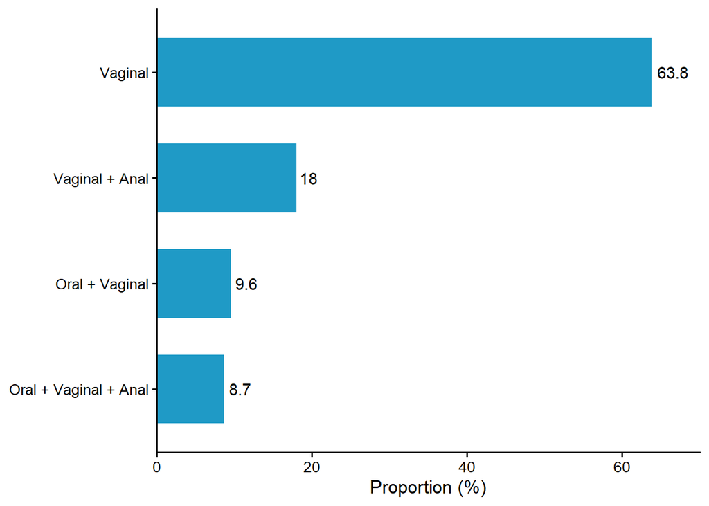

Figure 1. Distribution of sexual practices reported among participants

```r
fig1 <- TV_Global_data %>%
  filter(!is.na(typ_rap)) %>%
  count(typ_rap) %>%
  mutate(prop = 100 * n / sum(n)) %>%

  ggplot(aes(x = prop,
             y = fct_reorder(typ_rap, prop))) +

  geom_col(fill = "#1f9ac6", width = 0.65) +

  geom_text(aes(label = round(prop, 1)),
            hjust = -0.2,
            size = 4) +

  scale_x_continuous(
    limits = c(0, 70),
    expand = c(0, 0)
  ) +

  labs(
    x = "Proportion (%)",
    y = NULL
  ) +

  theme_classic(base_size = 13)



# Save figure
ggplot2::ggsave(
  filename = here::here(
    "output",
    "Figure 1. Distribution of sexual practices reported among participants.png"
  ),
  plot = fig1,
  width = 10,
  height = 6,
  dpi = 600,
  units = "in",
  bg = "white")

fig1
```

Vaginal intercourse was the most commonly reported sexual practice (63.8%). Combined sexual practices including vaginal and anal intercourse were reported by 18.0% of participants.

## 5.3 **Distribution of Reported STI Symptoms**

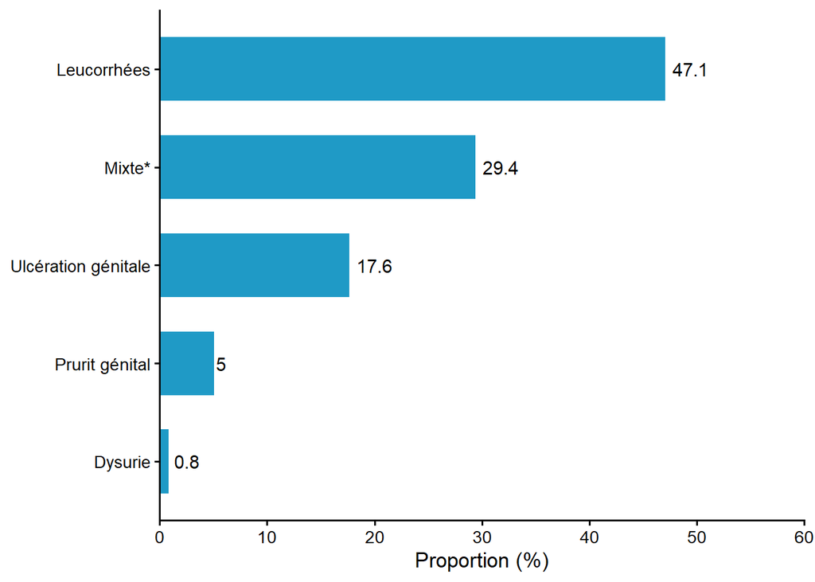

Figure 2. Distribution of sexually transmitted infection (STI) symptoms reported among symptomatic participants (n = 119)

```r
fig2 <- TV_Global_data %>%
  filter(symp_ist_med == "Oui",
         !is.na(quel_sympt_cat_med)) %>%

  count(quel_sympt_cat_med) %>%

  mutate(prop = 100 * n / sum(n)) %>%

  ggplot(aes(x = prop,
             y = fct_reorder(quel_sympt_cat_med, prop))) +

  geom_col(fill = "#1f9ac6", width = 0.65) +

  geom_text(aes(label = round(prop,1)),
            hjust = -0.2,
            size = 4) +

  scale_x_continuous(
    limits = c(0, 60),
    expand = c(0,0)
  ) +

  labs(
    x = "Proportion (%)",
    y = NULL
  ) +

  theme_classic(base_size = 13)


# Save figure
ggplot2::ggsave(
  filename = here::here(
    "output",
    "Figure 2. Distribution of sexually transmitted infection (STI) symptoms reported among symptomatic participants.png"
  ),
  plot = fig2,
  width = 10,
  height = 6,
  dpi = 600,
  units = "in",
  bg = "white")


fig2
```

Among the 119 participants reporting STI symptoms, leucorrhea was the most frequently reported symptom (47.1%), followed by mixed symptoms (29.4%) and genital ulceration (17.6%).

## 5.4 **Distribution of Reported STI Symptoms from binary variables**

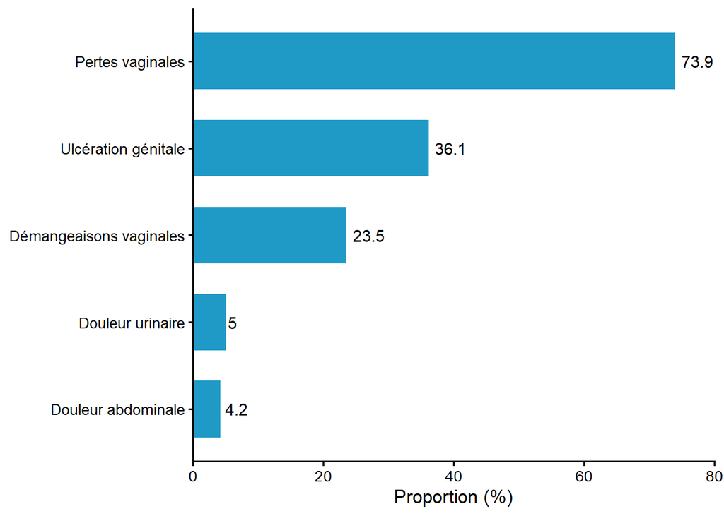

Figure 3. Distribution of reported sexually transmitted infection (STI) symptoms based on binary symptom variables

```r
symptomes_plot <- TV_Global_data %>%
  dplyr::select(
    `Pertes vaginales`,
    `Ulcération génitale`,
    `Démangeaisons vaginales`,
    `Douleur urinaire`,
    `Douleur abdominale`
  )


symptomes_summary <- symptomes_plot %>%
  summarise(across(everything(),
                   ~ mean(. == "Oui", na.rm = TRUE))) %>%
  pivot_longer(cols = everything(),
               names_to = "Symptôme",
               values_to = "Proportion") %>%
  mutate(Proportion = Proportion * 100) %>%
  arrange(desc(Proportion)) %>%   # decreasing sorting
  mutate(Symptôme = forcats::fct_reorder(Symptôme, Proportion))  # clear order

# Graph
fig3 <- ggplot(symptomes_summary,
                     aes(x = Proportion,
                         y = Symptôme)) +

  geom_col(fill = "#1f9ac6", width = 0.65) +

  geom_text(aes(label = round(Proportion, 1)),
            hjust = -0.2,
            size = 4) +

  scale_x_continuous(
    limits = c(0, 80),
    expand = c(0, 0)  # remove unnecessary space
  ) +

  labs(
    x = "Proportion (%)",
    y = NULL
  ) +

  theme_classic(base_size = 13)

fig3
```

```r
# Save figure
ggplot2::ggsave(
  filename = here::here(
    "output",
    "Figure 3. Distribution of reported sexually transmitted infection (STI) symptoms based on binary symptom variables.png"
  ),
  plot = fig3,
  width = 10,
  height = 6,
  dpi = 600,
  units = "in",
  bg = "white")
```

## 5.5 **Distribution of Reported STI Symptoms for all modalities**

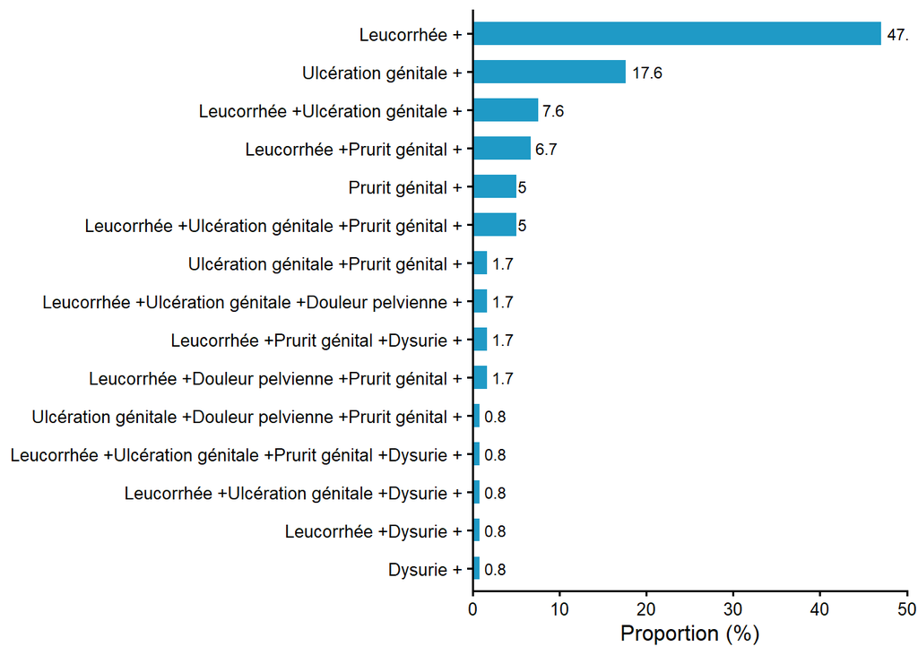

Figure 4. Distribution of all reported sexually transmitted infection (STI) symptom modalities

```r
summary_sympt <- TV_Global_data %>%
  filter(quel_sympt_cat != "Valid") %>%
  count(quel_sympt_cat) %>%
  mutate(prop = 100 * n / sum(n))


fig4 <- summary_sympt %>%
  ggplot(aes(x = prop,
             y = forcats::fct_reorder(quel_sympt_cat, prop))) +

  geom_col(fill = "#1f9ac6", width = 0.6) +

  geom_text(aes(label = round(prop, 1)),
            hjust = -0.2,
            size = 3) +

  scale_x_continuous(
    limits = c(0, 50),
    expand = c(0, 0)  # remove unnecessary space
  ) +

  labs(
    x = "Proportion (%)",
    y = NULL
  ) +

  theme_classic(base_size = 12)


# Save figure
ggplot2::ggsave(
  filename = here::here(
    "output",
    "Figure 4. Distribution of all reported sexually transmitted infection (STI) symptom modalities.png"
  ),
  plot = fig3,
  width = 10,
  height = 6,
  dpi = 600,
  units = "in",
  bg = "white")


fig4
```

## 5.6 **Prevalence of Major Sexually Transmitted Infections**

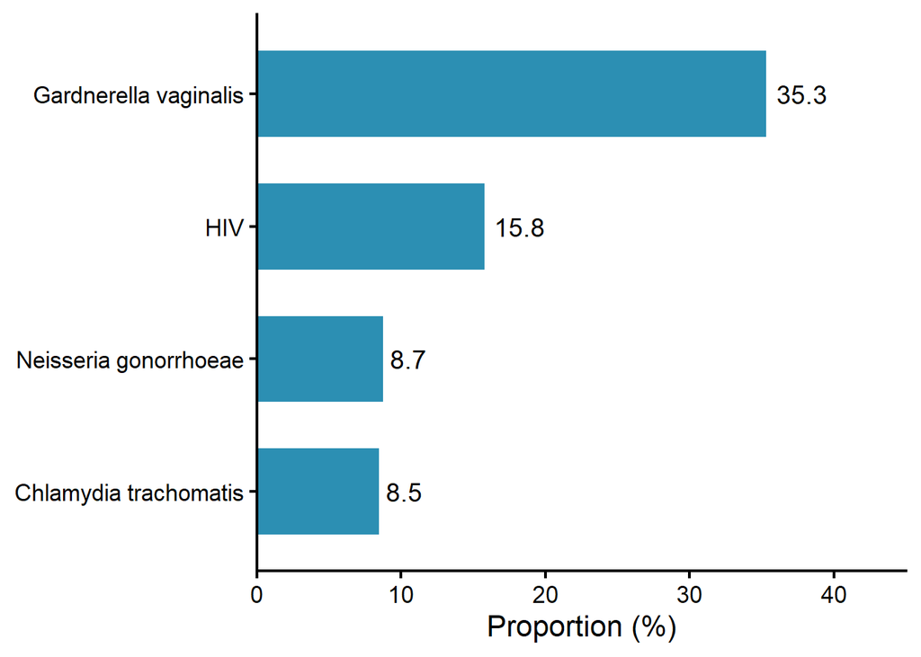

Figure 5. Prevalence of major sexually transmitted infections among study participants

```r
plot_ist <- TV_Global_data %>%
  summarise(
    HIV = mean(statut_VIH == "Positif", na.rm = TRUE)*100,
    `Gardnerella vaginalis` = mean(GV == "Positif", na.rm = TRUE)*100,
    `Chlamydia trachomatis` = mean(CT == "Positif", na.rm = TRUE)*100,
    `Neisseria gonorrhoeae` = mean(NG == "Positif", na.rm = TRUE)*100
  ) %>%
  tidyr::pivot_longer(cols = everything(),
                      names_to = "infection",
                      values_to = "prop")

fig5 <- ggplot(plot_ist,
       aes(x = prop,
           y = fct_reorder(infection, prop))) +

  geom_col(fill = "#2c8fb3", width = 0.65) +

  geom_text(aes(label = round(prop,1)),
            hjust = -0.2,
            size = 5) +

  scale_x_continuous(
    limits = c(0,45),
    expand = c(0,0)
  ) +

  labs(
    x = "Proportion (%)",
    y = NULL
  ) +

  theme_classic(base_size = 16)


# Save figure
ggplot2::ggsave(
  filename = here::here(
    "output",
    "Figure 5. Prevalence of major sexually transmitted infections among study participants.png"
  ),
  plot = fig5,
  width = 10,
  height = 6,
  dpi = 600,
  units = "in",
  bg = "white")

fig5
```

HIV infection was observed in 15.8% of participants. Gardnerella vaginalis infection was detected in 35.3% of participants, while Chlamydia trachomatis and Neisseria gonorrhoeae infections were identified in 8.5% and 8.7% of participants, respectively.

## 5.7 **Descriptive statistics for Continuous Variables**

```r
continuous_vars <- c(
  "age",
  "rapsex1",
  "sexpayan1",
  "anciennete_profession",
  "client_sem",
  "ph"
)

continuous_table <- data.frame(
  Variable = continuous_vars,
  Min = sapply(TV_Global_data[continuous_vars], function(x) min(x, na.rm = TRUE)),
  Q1 = sapply(TV_Global_data[continuous_vars], function(x) quantile(x, 0.25, na.rm = TRUE)),
  Median = sapply(TV_Global_data[continuous_vars], function(x) median(x, na.rm = TRUE)),
  Mean = sapply(TV_Global_data[continuous_vars], function(x) mean(x, na.rm = TRUE)),
  SD = sapply(TV_Global_data[continuous_vars], function(x) sd(x, na.rm = TRUE)),
  Q3 = sapply(TV_Global_data[continuous_vars], function(x) quantile(x, 0.75, na.rm = TRUE)),
  Max = sapply(TV_Global_data[continuous_vars], function(x) max(x, na.rm = TRUE))
)

continuous_table %>%
  kable(
    caption = "Distribution of Continuous Variables",
    align = "lccccccc",
    digits = 2
  ) %>%
  kable_styling(
    full_width = FALSE,
    bootstrap_options = c("striped","hover","condensed")
  )
```

Distribution of Continuous Variables

|  | Variable | Min | Q1 | Median | Mean | SD | Q3 | Max |
| --- | --- | --- | --- | --- | --- | --- | --- | --- |
| age | age | 18 | 26 | 32.0 | 33.62 | 10.13 | 40.0 | 68 |
| rapsex1 | rapsex1 | 7 | 16 | 18.0 | 17.81 | 2.89 | 19.0 | 30 |
| sexpayan1 | sexpayan1 | 14 | 20 | 23.0 | 25.50 | 7.81 | 30.0 | 51 |
| anciennete_profession | anciennete_profession | 0 | 2 | 5.5 | 8.18 | 8.06 | 11.0 | 52 |
| client_sem | client_sem | 0 | 3 | 4.0 | 5.41 | 5.00 | 6.0 | 50 |
| ph | ph | 5 | 5 | 5.0 | 5.40 | 0.66 | 5.5 | 9 |

The median age of participants was 32 years (IQR: 26-40). The median age at first sexual intercourse was 18 years, while the median age at first paid sexual intercourse was 23 years. The median duration of sex work was 5.5 years. Participants reported a median of four clients per week. The median vaginal pH was 5.0.

# 6 **Distribution of Trichomonas vaginalis Infection and Bivariate Analysis of Associated Factors**

## 6.1 **Overall Prevalence of Trichomonas vaginalis**

Description of overall prevalence of infection among participants.

```r
# Remove missing values
tv_data <- TV_Global_data %>%
  filter(!is.na(TV_EF))

# Counts
n_pos <- sum(tv_data$TV_EF == "Positif")
n_total <- nrow(tv_data)

# CI
ci <- prop.test(n_pos, n_total)$conf.int

prevalence_table <- data.frame(
  Count = n_pos,
  Total = n_total,
  Prevalence = round((n_pos/n_total)*100,1),
  CI_lower = round(ci[1]*100,1),
  CI_upper = round(ci[2]*100,1)
)

prevalence_table %>%
  kable(
    caption = "Overall prevalence of Trichomonas vaginalis",
    col.names = c("Positive cases","Total","Prevalence (%)","95% CI lower","95% CI upper"),
    align = "ccccc"
  ) %>%
  kable_styling(full_width = FALSE)
```

Overall prevalence of Trichomonas vaginalis

| Positive cases | Total | Prevalence (%) | 95% CI lower | 95% CI upper |
| --- | --- | --- | --- | --- |
| 34 | 357 | 9.5 | 6.8 | 13.2 |

The overall prevalence of *Trichomonas vaginalis* infection among female sex workers was 9.5% (95% CI: 6.8-13.2).

## 6.2 **Distribution Prevalence Across Participant Characteristics**

Prevalence estimates across sociodemographic, behavioral and clinical variables.

```r
analysis_vars <- c(
  "age_group","niv_educ","parten","clien_reg",
  "habita","otr_activ_cat","somme_sem","rapsex1_group",
  "sexpayan1_group","anciennete_profession_cat",
  "activ_prin","client_sem_cat","typ_rap",
  "toil_int","freq_toil","type_toil_rec",
  "preso_dern_rap","freq_pres","clien_reg",
  "symp_ist_med",
  "quel_sympt_cat_med",
  "leucorre",
  "aspect_col_cat","ph_cat",
  "statut_VIH","GV","CT","NG"
)


prevalence_by_var <- lapply(analysis_vars, function(v){

  df <- TV_Global_data %>%
    filter(!is.na(.data[[v]]), !is.na(TV_EF))

  tab <- table(df[[v]], df$TV_EF)

  res <- lapply(rownames(tab), function(cat){

    n_total <- sum(tab[cat,])
    n_pos <- tab[cat,"Positif"]

    ci <- binom.test(n_pos, n_total)$conf.int

    data.frame(
      Variable = v,
      Category = cat,
      Count_Positive = n_pos,
      Total = n_total,
      Prevalence = round((n_pos/n_total)*100,1),
      CI_lower = round(ci[1]*100,1),
      CI_upper = round(ci[2]*100,1)
    )

  }) %>% bind_rows()

  return(res)

}) %>% bind_rows()


prevalence_by_var %>%
  kable(
    caption = "Distribution of Trichomonas vaginalis prevalence across participant characteristics",
    col.names = c("Variable","Category","Positive","Total","Prevalence (%)","95% CI lower","95% CI upper"),
    align = "lcccccc"
  ) %>%
  kable_styling(
    full_width = FALSE,
    bootstrap_options = c("striped","hover","condensed")
  )
```

Distribution of Trichomonas vaginalis prevalence across participant characteristics

| Variable | Category | Positive | Total | Prevalence (%) | 95% CI lower | 95% CI upper |
| --- | --- | --- | --- | --- | --- | --- |
| age_group | < 20 | 1 | 9 | 11.1 | 0.3 | 48.2 |
| age_group | 20-29 | 10 | 132 | 7.6 | 3.7 | 13.5 |
| age_group | 30-39 | 11 | 121 | 9.1 | 4.6 | 15.7 |
| age_group | ≥ 40 | 12 | 95 | 12.6 | 6.7 | 21.0 |
| niv_educ | Non instruites | 6 | 53 | 11.3 | 4.3 | 23.0 |
| niv_educ | Primaire | 12 | 125 | 9.6 | 5.1 | 16.2 |
| niv_educ | Secondaire | 14 | 150 | 9.3 | 5.2 | 15.2 |
| niv_educ | Supérieur | 2 | 29 | 6.9 | 0.8 | 22.8 |
| parten | Non | 16 | 167 | 9.6 | 5.6 | 15.1 |
| parten | Oui | 18 | 189 | 9.5 | 5.7 | 14.6 |
| clien_reg | Non | 16 | 116 | 13.8 | 8.1 | 21.4 |
| clien_reg | Oui | 18 | 237 | 7.6 | 4.6 | 11.7 |
| habita | Collectif | 22 | 224 | 9.8 | 6.3 | 14.5 |
| habita | Individuel | 11 | 91 | 12.1 | 6.2 | 20.6 |
| habita | Maison close | 1 | 40 | 2.5 | 0.1 | 13.2 |
| otr_activ_cat | PS uniquement | 18 | 171 | 10.5 | 6.4 | 16.1 |
| otr_activ_cat | PS + Commerce/coiffure/couture | 11 | 154 | 7.1 | 3.6 | 12.4 |
| otr_activ_cat | PS + Autres* | 5 | 25 | 20.0 | 6.8 | 40.7 |
| somme_sem | < 5000 FCFA | 4 | 38 | 10.5 | 2.9 | 24.8 |
| somme_sem | 5005 - 25 000 FCFA | 20 | 207 | 9.7 | 6.0 | 14.5 |
| somme_sem | 25005 - 50 000 FCFA | 5 | 82 | 6.1 | 2.0 | 13.7 |
| somme_sem | 50005 - 100 000 FCFA | 1 | 17 | 5.9 | 0.1 | 28.7 |
| somme_sem | ≥ 100000 FCFA | 3 | 10 | 30.0 | 6.7 | 65.2 |
| rapsex1_group | <15 | 3 | 31 | 9.7 | 2.0 | 25.8 |
| rapsex1_group | 15-24 | 29 | 313 | 9.3 | 6.3 | 13.0 |
| rapsex1_group | 25-35 | 2 | 11 | 18.2 | 2.3 | 51.8 |
| sexpayan1_group | <15 | 2 | 3 | 66.7 | 9.4 | 99.2 |
| sexpayan1_group | 15-24 | 17 | 186 | 9.1 | 5.4 | 14.2 |
| sexpayan1_group | 25-34 | 10 | 114 | 8.8 | 4.3 | 15.5 |
| sexpayan1_group | ≥ 35 | 5 | 52 | 9.6 | 3.2 | 21.0 |

[output cut: 58 more lines]

## 6.3 **Bivariate Analysis**

Bivariate analysis was conducted to explore the association between participant characteristics and *Trichomonas vaginalis* infection.

The association between categorical variables and infection status was assessed using the Pearson chi-square test or Fisher’s exact test when expected cell counts were below five.

```r
bivariate_test <- function(var){

  tab <- table(TV_Global_data[[var]], TV_Global_data$TV_EF)

  if(any(tab < 5)){
    test <- fisher.test(tab)
    method <- "Fisher exact"
  } else {
    test <- chisq.test(tab)
    method <- "Chi-square"
  }

  data.frame(
    Variable = var,
    Method = method,
    p_value = round(test$p.value,4)
  )
}

vars <- c(
"age_group","niv_educ","parten","clien_reg","habita","otr_activ_cat","somme_sem","rapsex1_group","sexpayan1_group","anciennete_profession_cat",
"activ_prin","client_sem_cat","typ_rap",
"toil_int","freq_toil","type_toil_rec",
"preso_dern_rap","freq_pres","clien_reg","symp_ist_med","quel_sympt_cat_med",
"leucorre","aspect_col_cat","ph_cat","statut_VIH","GV","CT","NG"
)

bivariate_results <- lapply(vars, bivariate_test) %>%
  bind_rows()


bivariate_results %>%
  kable(
    caption = "Bivariate analysis of factors associated with Trichomonas vaginalis infection",
    col.names = c("Variable","Statistical test","p-value"),
    align = c("l","c","c"),
    digits = 3
  ) %>%
  kable_styling(
    full_width = FALSE,
    bootstrap_options = c("striped","hover","condensed")
  )
```

Bivariate analysis of factors associated with Trichomonas vaginalis infection

| Variable | Statistical test | p-value |
| --- | --- | --- |
| age_group | Fisher exact | 0.552 |
| niv_educ | Fisher exact | 0.947 |
| parten | Chi-square | 1.000 |
| clien_reg | Chi-square | 0.096 |
| habita | Fisher exact | 0.225 |
| otr_activ_cat | Chi-square | 0.116 |
| somme_sem | Fisher exact | 0.201 |
| rapsex1_group | Fisher exact | 0.473 |
| sexpayan1_group | Fisher exact | 0.069 |
| anciennete_profession_cat | Fisher exact | 0.780 |
| activ_prin | Chi-square | 0.685 |
| client_sem_cat | Chi-square | 0.569 |
| typ_rap | Fisher exact | 0.332 |
| toil_int | Chi-square | 1.000 |
| freq_toil | Fisher exact | 0.268 |
| type_toil_rec | Fisher exact | 0.902 |
| preso_dern_rap | Chi-square | 0.609 |
| freq_pres | Fisher exact | 0.597 |
| clien_reg | Chi-square | 0.096 |
| symp_ist_med | Chi-square | 0.111 |
| quel_sympt_cat_med | Fisher exact | 0.783 |
| leucorre | Fisher exact | 0.421 |
| aspect_col_cat | Fisher exact | 0.050 |
| ph_cat | Fisher exact | 0.178 |
| statut_VIH | Chi-square | 0.248 |
| GV | Fisher exact | 0.000 |
| CT | Fisher exact | 0.754 |
| NG | Fisher exact | 0.338 |

Among the variables examined, infection with *Gardnerella vaginalis* was significantly associated with *Trichomonas vaginalis* infection (p < 0.001). Other variables did not show statistically significant associations in the bivariate analysis.

# 7 **Identification of Factors Associated with *Trichomonas vaginalis* Infection**

To identify factors associated with Trichomonas vaginalis infection, logistic regression analyses were performed.

## 7.1 **Univariable Logistic Regression Analysis**

First, univariable logistic regression models were fitted for each explanatory variable to estimate crude associations with infection status. Variables with a p-value < 0.20 in univariable analysis, as well as variables considered biologically relevant based on previous literature, were considered for inclusion in the multivariable model.

For each variable, crude odds ratios (OR) and their 95% confidence intervals (95% CI) were estimated.

```r
# Variables selected based on chi-square/Fisher tests and biological plausibility
vars <- c(

  # 1. Sociodemographic factors
  "age_group",
  "niv_educ",
  "parten",
  "habita",

  # 2. Sexual behaviours and symptoms
  "rapsex1_group",
  "sexpayan1_group",
  "anciennete_profession_cat",
  "activ_prin",
  "client_sem_cat",
  "typ_rap",
  "toil_int",
  "freq_toil",
  "type_toil_rec",
  "clien_reg",
  "symp_ist_med",

  # 3. Sexually transmitted infections
  "statut_VIH",
  "GV",
  "CT",
  "NG"
)



univariate_logistic <- function(var){

  formula <- as.formula(paste("TV_EF ~", var))

  model <- glm(
    formula,
    data = TV_Global_data,
    family = binomial
  )

  results <- summary(model)$coefficients

  OR <- exp(coef(model))
  CI <- exp(confint(model))

  # Number of observations used in the model
  n_used <- nobs(model)

  data.frame(
    Variable = var,
    Category = rownames(results),
    N = n_used,
    OR = round(OR,2),
    CI_lower = round(CI[,1],2),
    CI_upper = round(CI[,2],2),
    p_value = round(results[,4],4)
  )
}


univariate_results <- lapply(vars, univariate_logistic) %>%
  bind_rows() %>%
filter(Category != "(Intercept)")
univariate_results %>%
  kable(
    caption = "Univariable logistic regression analysis of factors associated with Trichomonas vaginalis infection",
    col.names = c("Variable","Category","N","OR","95% CI lower","95% CI upper","p-value"),
    align = "lcccccc"
  ) %>%
  kable_styling(
    full_width = FALSE,
    bootstrap_options = c("striped","hover","condensed")
  )
```

Univariable logistic regression analysis of factors associated with Trichomonas vaginalis infection

|  | Variable | Category | N | OR | 95% CI lower | 95% CI upper | p-value |
| --- | --- | --- | --- | --- | --- | --- | --- |
| age_group20-29 | age_group | age_group20-29 | 357 | 0.66 | 0.10 | 12.79 | 0.7039 |
| age_group30-39 | age_group | age_group30-39 | 357 | 0.80 | 0.13 | 15.54 | 0.8402 |
| age_group≥ 40 | age_group | age_group≥ 40 | 357 | 1.16 | 0.19 | 22.43 | 0.8952 |
| niv_educPrimaire | niv_educ | niv_educPrimaire | 357 | 0.83 | 0.30 | 2.51 | 0.7280 |
| niv_educSecondaire | niv_educ | niv_educSecondaire | 357 | 0.81 | 0.30 | 2.39 | 0.6769 |
| niv_educSupérieur | niv_educ | niv_educSupérieur | 357 | 0.58 | 0.08 | 2.72 | 0.5227 |
| partenOui | parten | partenOui | 356 | 0.99 | 0.49 | 2.04 | 0.9854 |
| habitaIndividuel | habita | habitaIndividuel | 355 | 1.26 | 0.57 | 2.67 | 0.5523 |
| habitaMaison close | habita | habitaMaison close | 355 | 0.24 | 0.01 | 1.17 | 0.1632 |
| rapsex1_group15-24 | rapsex1_group | rapsex1_group15-24 | 355 | 0.95 | 0.31 | 4.15 | 0.9399 |
| rapsex1_group25-35 | rapsex1_group | rapsex1_group25-35 | 355 | 2.07 | 0.24 | 14.55 | 0.4612 |
| sexpayan1_group15-24 | sexpayan1_group | sexpayan1_group15-24 | 355 | 0.05 | 0.00 | 0.55 | 0.0168 |
| sexpayan1_group25-34 | sexpayan1_group | sexpayan1_group25-34 | 355 | 0.05 | 0.00 | 0.54 | 0.0167 |
| sexpayan1_group≥ 35 | sexpayan1_group | sexpayan1_group≥ 35 | 355 | 0.05 | 0.00 | 0.65 | 0.0253 |
| anciennete_profession_cat2-5 ans | anciennete_profession_cat | anciennete_profession_cat2-5 ans | 354 | 1.26 | 0.41 | 4.73 | 0.7004 |
| anciennete_profession_cat> 5 ans | anciennete_profession_cat | anciennete_profession_cat> 5 ans | 354 | 1.53 | 0.55 | 5.47 | 0.4559 |
| activ_prinOui | activ_prin | activ_prinOui | 355 | 1.24 | 0.61 | 2.53 | 0.5587 |
| client_sem_cat5-9 | client_sem_cat | client_sem_cat5-9 | 348 | 0.64 | 0.26 | 1.45 | 0.3069 |
| client_sem_cat≥ 10 | client_sem_cat | client_sem_cat≥ 10 | 348 | 0.77 | 0.25 | 2.00 | 0.6176 |
| typ_rapVaginal + Anal | typ_rap | typ_rapVaginal + Anal | 356 | 1.34 | 0.50 | 3.23 | 0.5260 |
| typ_rapOral + Vaginal | typ_rap | typ_rapOral + Vaginal | 356 | 2.35 | 0.80 | 6.09 | 0.0944 |
| typ_rapOral + Vaginal + Anal | typ_rap | typ_rapOral + Vaginal + Anal | 356 | 0.75 | 0.12 | 2.79 | 0.7149 |
| toil_intOui | toil_int | toil_intOui | 356 | 0.92 | 0.36 | 2.81 | 0.8669 |
| freq_toilAprès chaque rapport | freq_toil | freq_toilAprès chaque rapport | 307 | 1.48 | 0.51 | 3.84 | 0.4376 |
| freq_toilIrrégulier | freq_toil | freq_toilIrrégulier | 307 | 0.74 | 0.17 | 2.35 | 0.6461 |
| freq_toilAu moins une fois par semaine | freq_toil | freq_toilAu moins une fois par semaine | 307 | 2.72 | 0.72 | 8.52 | 0.1050 |
| type_toil_recSavon | type_toil_rec | type_toil_recSavon | 305 | 0.86 | 0.24 | 2.47 | 0.8017 |
| type_toil_recPlante | type_toil_rec | type_toil_recPlante | 305 | 1.42 | 0.21 | 5.68 | 0.6601 |
| type_toil_recProduits | type_toil_rec | type_toil_recProduits | 305 | 1.28 | 0.35 | 3.75 | 0.6725 |
| type_toil_recAutres | type_toil_rec | type_toil_recAutres | 305 | 1.24 | 0.19 | 4.89 | 0.7839 |
| clien_regOui | clien_reg | clien_regOui | 353 | 0.51 | 0.25 | 1.06 | 0.0674 |
| symp_ist_medOui | symp_ist_med | symp_ist_medOui | 357 | 1.90 | 0.92 | 3.88 | 0.0780 |
| statut_VIHPositif | statut_VIH | statut_VIHPositif | 349 | 1.83 | 0.74 | 4.15 | 0.1651 |
| GVPositif | GV | GVPositif | 357 | 0.16 | 0.04 | 0.45 | 0.0027 |
| CTPositif | CT | CTPositif | 355 | 0.65 | 0.10 | 2.32 | 0.5740 |
| NGPositif | NG | NGPositif | 355 | 0.29 | 0.02 | 1.44 | 0.2359 |

Several variables showed potential associations with infection and were considered for inclusion in the multivariable model based on statistical significance and biological plausibility.

# 8 **Multivariable Logistic Regression Analysis**

A multivariable logistic regression model was then constructed to identify factors independently associated with Trichomonas vaginalis infection. Variable selection was performed using a stepwise procedure based on the Akaike Information Criterion (AIC) to obtain the most parsimonious model.

Adjusted odds ratios (AOR) and their 95% confidence intervals (95% CI) were calculated to identify factors independently associated with Trichomonas vaginalis infection.

```r
# Dataset complet sans valeurs manquantes pour les variables du modèle

vars_model <- c(
"TV_EF",
"age_group",
"niv_educ",
"habita",
"sexpayan1_group",
"client_sem_cat",
"activ_prin",
"freq_toil",
"symp_ist_med",
"GV",
"NG",
"statut_VIH"
)

TV_model_data <- TV_Global_data %>%
dplyr::select(all_of(vars_model)) %>%
na.omit()


## Sample size used in the regression model
nrow(TV_model_data)
```

```
## [1] 288
```

```r
cat("Sample size used in multivariable analysis:", nrow(TV_model_data))
```

```
## Sample size used in multivariable analysis: 288
```

```r
# Multivariable Logistic Regression Model (Initial Full Model)

full_model <- glm(
TV_EF ~ age_group +
niv_educ +
habita +
sexpayan1_group +
client_sem_cat +
activ_prin +
freq_toil +
symp_ist_med +
GV +
NG +
statut_VIH,
data = TV_model_data,
family = binomial
)


# Variable selection using Stepwise Logistic Regression
## Stepwise Logistic Regression (based on AIC)

step_model <- stepAIC(
full_model,
direction = "both",
trace = FALSE
)



# Extraction of Adjusted Odds Ratios (AOR)
## Adjusted Odds Ratios and 95% Confidence Intervals

OR <- exp(coef(step_model))
CI <- exp(confint(step_model))
multiv_results <- data.frame(
Variable = rownames(summary(step_model)$coefficients),
AOR = round(OR,2),
CI_lower = round(CI[,1],2),
CI_upper = round(CI[,2],2),
p_value = round(summary(step_model)$coefficients[,4],4)
)



# Multivariable Logistic Regression Results Table
multiv_results %>%
filter(Variable != "(Intercept)") %>%
kable(
caption = "Multivariable logistic regression analysis of factors associated with Trichomonas vaginalis infection",
col.names = c("Variable","AOR","95% CI lower","95% CI upper","p-value"),
align = "lcccc"
) %>%
kable_styling(
full_width = FALSE,
bootstrap_options = c("striped","hover","condensed")
)
```

Multivariable logistic regression analysis of factors associated with Trichomonas vaginalis infection

|  | Variable | AOR | 95% CI lower | 95% CI upper | p-value |
| --- | --- | --- | --- | --- | --- |
| age_group20-29 | age_group20-29 | 3262132.64 | 0.00 | 2.676862e+169 | 0.9918 |
| age_group30-39 | age_group30-39 | 8497370.83 | 0.00 | NA | 0.9913 |
| age_group≥ 40 | age_group≥ 40 | 12200533.20 | 0.00 | NA | 0.9911 |
| sexpayan1_group15-24 | sexpayan1_group15-24 | 0.01 | 0.00 | 2.100000e-01 | 0.0043 |
| sexpayan1_group25-34 | sexpayan1_group25-34 | 0.01 | 0.00 | 1.700000e-01 | 0.0030 |
| sexpayan1_group≥ 35 | sexpayan1_group≥ 35 | 0.01 | 0.00 | 1.700000e-01 | 0.0034 |
| symp_ist_medOui | symp_ist_medOui | 2.40 | 1.00 | 5.810000e+00 | 0.0486 |
| GVPositif | GVPositif | 0.11 | 0.02 | 4.000000e-01 | 0.0049 |

## 8.1 **Model adequacy was evaluated using**

- Model adequacy was evaluated using:
- Akaike Information Criterion (AIC)
- Hosmer-Lemeshow goodness-of-fit test
- Variance Inflation Factor (VIF) to assess multicollinearity between variables.

```r
# Model evaluation (Model diagnostics)
## AIC of the final model
AIC(step_model)
```

```
## [1] 172.4202
```

```r
# Hosmer-Lemeshow test (Goodness of fit)
hoslem.test(
as.numeric(TV_model_data$TV_EF) - 1,
fitted(step_model)
)
```

```
##
##  Hosmer and Lemeshow goodness of fit (GOF) test
##
## data:  as.numeric(TV_model_data$TV_EF) - 1, fitted(step_model)
## X-squared = 3.3449, df = 8, p-value = 0.9109
```

```r
# Multicollinearity (VIF)
vif(step_model)
```

```
##                     GVIF Df GVIF^(1/(2*Df))
## age_group       1.761464  3        1.098953
## sexpayan1_group 1.826493  3        1.105613
## symp_ist_med    1.092001  1        1.044988
## GV              1.051358  1        1.025358
```

# 9 **Comparison of Diagnostic Methods for the Detection of Trichomonas vaginalis**

This section evaluates the diagnostic performance of wet mount microscopy compared with PCR for the detection of Trichomonas vaginalis. PCR was considered the reference method.

## 9.1 **Prevalence of *Trichomonas vaginalis* According to Diagnostic Method**

This analysis estimates the prevalence of Trichomonas vaginalis detected by wet mount microscopy and PCR among participants with valid PCR results. Prevalence proportions and their 95% confidence intervals were calculated using exact binomial methods.

```r
# Filter dataset to keep only valid PCR tests
tv_diag <- TV_Global_data %>%
  filter(TV_PCR_status == "Test valide") %>%
  filter(!is.na(TV_EF), !is.na(TV))


# Total sample
n_total <- nrow(tv_diag)


# Prevalence according to each technique
# EF prevalence
ef_pos <- sum(tv_diag$TV_EF == "Positif")
ef_prev <- binom.test(ef_pos, n_total)

# PCR prevalence
pcr_pos <- sum(tv_diag$TV == "Positif")
pcr_prev <- binom.test(pcr_pos, n_total)

# Prevalence table
prev_table <- data.frame(
  Method = c("Wet mount microscopy (EF)", "PCR"),
  Positive = c(ef_pos, pcr_pos),
  Total = c(n_total, n_total),
  Prevalence = round(c(ef_pos/n_total, pcr_pos/n_total)*100,1),
  CI_lower = round(c(ef_prev$conf.int[1], pcr_prev$conf.int[1])*100,1),
  CI_upper = round(c(ef_prev$conf.int[2], pcr_prev$conf.int[2])*100,1)
)

prev_table %>%
  kable(
    caption = "Prevalence of Trichomonas vaginalis according to diagnostic technique",
    col.names = c("Diagnostic method","Positive","Total","Prevalence (%)","95% CI lower","95% CI upper")
  ) %>%
  kable_styling(full_width = FALSE)
```

Prevalence of Trichomonas vaginalis according to diagnostic technique

| Diagnostic method | Positive | Total | Prevalence (%) | 95% CI lower | 95% CI upper |
| --- | --- | --- | --- | --- | --- |
| Wet mount microscopy (EF) | 17 | 198 | 8.6 | 5.1 | 13.4 |
| PCR | 21 | 198 | 10.6 | 6.7 | 15.8 |

Among the 198 participants with valid PCR results, the prevalence of Trichomonas vaginalis infection was 10.6% according to PCR and 8.6% according to wet mount microscopy.

## 9.2 **Comparison of Detection Proportions Between Diagnostic Methods (McNemar Test)**

The McNemar test was used to compare the detection proportions between wet mount microscopy and PCR. This test is appropriate for paired diagnostic data and evaluates whether the two methods differ significantly in their ability to detect infection.

```r
# Create contingency table
diag_table <- tv_diag %>%
  with(table(Test = TV_EF, Outcome = TV)) %>%
  .[c("Positif","Négatif"), c("Positif","Négatif"), drop = FALSE]

diag_table
```

```
##          Outcome
## Test      Positif Négatif
##   Positif       5      12
##   Négatif      16     165
```

```r
# McNemar test (comparison of methods)
mcnemar_test <- mcnemar.test(diag_table)
mcnemar_test
```

```
##
##  McNemar's Chi-squared test with continuity correction
##
## data:  diag_table
## McNemar's chi-squared = 0.32143, df = 1, p-value = 0.5708
```

The McNemar test was used to compare the detection proportions between wet mount microscopy and PCR. No statistically significant difference was observed between the two diagnostic methods (p = 0.571).

## 9.3 **Agreement Between Wet Mount Microscopy and PCR**

Agreement between the two diagnostic methods was assessed using a contingency table and Cohen’s Kappa coefficient. This analysis quantifies the level of concordance between microscopy and PCR results beyond what would be expected by chance.

```r
# Display table
diag_table %>%
  kable(
    caption = "Agreement between wet mount microscopy (EF) and PCR for detection of Trichomonas vaginalis",
    row.names = TRUE
  ) %>%
  kable_styling(
    full_width = FALSE,
    bootstrap_options = c("striped","hover","condensed")
  )
```

Agreement between wet mount microscopy (EF) and PCR for detection of Trichomonas vaginalis

|  | Positif | Négatif |
| --- | --- | --- |
| Positif | 5 | 12 |
| Négatif | 16 | 165 |

```r
# Kappa agreement
kappa_result <- irr::kappa2(tv_diag[,c("TV_EF","TV")])
kappa_result
```

```
##  Cohen's Kappa for 2 Raters (Weights: unweighted)
##
##  Subjects = 198
##    Raters = 2
##     Kappa = 0.186
##
##         z = 2.63
##   p-value = 0.00844
```

Agreement between wet mount microscopy and PCR was assessed using Cohen’s Kappa coefficient. The Kappa value was 0.186 (p = 0.008), indicating a low level of agreement between the two diagnostic methods.

## 9.4 **Diagnostic Performance of Wet Mount Microscopy**

Using PCR as the reference method, the diagnostic performance of wet mount microscopy was evaluated by estimating sensitivity, specificity, positive predictive value (PPV), negative predictive value (NPV), and likelihood ratios. These indicators provide a comprehensive assessment of the ability of microscopy to correctly identify infected and non-infected individuals.

```r
# Diagnostic Performance
# Diagnostic performance statistics
diag_perf <- epi.tests(diag_table)
print(diag_perf)
```

```
##           Outcome +    Outcome -      Total
## Test +            5           12         17
## Test -           16          165        181
## Total            21          177        198
##
## Point estimates and 95% CIs:
## --------------------------------------------------------------
## Apparent prevalence *                  0.09 (0.05, 0.13)
## True prevalence *                      0.11 (0.07, 0.16)
## Sensitivity *                          0.24 (0.08, 0.47)
## Specificity *                          0.93 (0.88, 0.96)
## Positive predictive value *            0.29 (0.10, 0.56)
## Negative predictive value *            0.91 (0.86, 0.95)
## Positive likelihood ratio              3.51 (1.37, 8.99)
## Negative likelihood ratio              0.82 (0.64, 1.04)
## False T+ proportion for true D- *      0.07 (0.04, 0.12)
## False T- proportion for true D+ *      0.76 (0.53, 0.92)
## False T+ proportion for T+ *           0.71 (0.44, 0.90)
## False T- proportion for T- *           0.09 (0.05, 0.14)
## Correctly classified proportion *      0.86 (0.80, 0.90)
## --------------------------------------------------------------
## * Exact CIs
```

Using PCR as the reference method, wet mount microscopy showed low sensitivity (24%) but high specificity (93%). The positive predictive value was 29%, and the negative predictive value was 91%. These findings indicate that wet mount microscopy has limited ability to detect true infections but performs well in identifying non-infected individuals.

## 9.5 **Distribution de la prévalence de Trichomonas vaginalis selon le statut symptomatique et les méthodes diagnostiques**

```r
## Fonction
calc_n_pct <- function(data, var){
  n <- sum(data[[var]] == "Positif", na.rm = TRUE)
  N <- sum(!is.na(data[[var]]))
  pct <- round(100*n/N,1)
  paste0(n, "/", N, " (", pct, ")")
}

# Fonction pour format p-value
format_p <- function(p){
  if(is.na(p)) return("")
  if(p < 0.001) return("<0.001")
  return(sprintf("%.3f", p))
}


## Sous-population
tv_diag <- TV_Global_data %>%
  dplyr::filter(TV_PCR_status == "Test valide") %>%
  dplyr::filter(!is.na(TV_EF), !is.na(TV))


## TABLE PAR SYMPTÔMES
# EF total
EF_total <- TV_Global_data %>%
  dplyr::group_by(symp_ist_med) %>%
  dplyr::summarise(EF_total = calc_n_pct(dplyr::cur_data(), "TV_EF"), .groups="drop")
# EF sous-pop
EF_diag <- tv_diag %>%
  dplyr::group_by(symp_ist_med) %>%
  dplyr::summarise(EF_diag = calc_n_pct(dplyr::cur_data(), "TV_EF"), .groups="drop")

# PCR
PCR_diag <- tv_diag %>%
  dplyr::group_by(symp_ist_med) %>%
  dplyr::summarise(PCR = calc_n_pct(dplyr::cur_data(), "TV"), .groups="drop")

# GLOBAL
GLOBAL_diag <- tv_diag %>%
  dplyr::group_by(symp_ist_med) %>%
  dplyr::summarise(GLOBAL = calc_n_pct(dplyr::cur_data(), "TV_Global"), .groups="drop")


## FUSION
table_final <- EF_total %>%
  dplyr::left_join(EF_diag, by="symp_ist_med") %>%
  dplyr::left_join(PCR_diag, by="symp_ist_med") %>%
  dplyr::left_join(GLOBAL_diag, by="symp_ist_med")


## p-values
p_EF_total <- chisq.test(table(TV_Global_data$symp_ist_med, TV_Global_data$TV_EF))$p.value
p_EF_diag  <- chisq.test(table(tv_diag$symp_ist_med, tv_diag$TV_EF))$p.value
p_PCR      <- chisq.test(table(tv_diag$symp_ist_med, tv_diag$TV))$p.value
p_GLOBAL   <- chisq.test(table(tv_diag$symp_ist_med, tv_diag$TV_Global))$p.value


## LIGNE p + TOTAL
p_row <- data.frame(
  symp_ist_med = "p*",
  EF_total = format_p(p_EF_total),
  EF_diag  = format_p(p_EF_diag),
  PCR      = format_p(p_PCR),
  GLOBAL   = format_p(p_GLOBAL),
  stringsAsFactors = FALSE
)

total_row <- data.frame(
  symp_ist_med = "Total",
  EF_total = calc_n_pct(TV_Global_data, "TV_EF"),
  EF_diag  = calc_n_pct(tv_diag, "TV_EF"),
  PCR      = calc_n_pct(tv_diag, "TV"),
  GLOBAL   = calc_n_pct(tv_diag, "TV_Global"),
  stringsAsFactors = FALSE
)

final_table <- dplyr::bind_rows(table_final, p_row, total_row)

final_table
```

```
## # A tibble: 4 × 5
##   symp_ist_med EF_total      EF_diag      PCR           GLOBAL
##   <chr>        <chr>         <chr>        <chr>         <chr>
## 1 Non          18/238 (7.6)  9/134 (6.7)  11/134 (8.2)  19/134 (14.2)
## 2 Oui          16/119 (13.4) 8/64 (12.5)  10/64 (15.6)  14/64 (21.9)
## 3 p*           0.111         0.277        0.181         0.248
## 4 Total        34/357 (9.5)  17/198 (8.6) 21/198 (10.6) 33/198 (16.7)
```

# 10 **Conclusion**

This study provides updated epidemiological evidence on the burden of Trichomonas vaginalis infection among female sex workers in Lomé.

The results highlight moderate prevalence and suggest potential interactions with other sexually transmitted infections.

Wet mount microscopy showed limited sensitivity compared with PCR, supporting the need for improved diagnostic approaches in STI surveillance programs.